# Lab2

Colter King

9/3/2020

# Tasks

## Task 1

Find the working directory

```r
getwd()
```

```
## [1] "C:/Users/Colter King/Documents/RProject/MATH4753KingProj1/Lab2"
```

## Task 2

Read in EPAGAS deta and display the first 6 points.

```r
EPAGAS = read.csv("EPAGAS.csv")
head(EPAGAS)
```

```
##    MPG
## 1 36.3
## 2 41.0
## 3 36.9
## 4 37.1
## 5 44.9
## 6 36.8
```

## Task 3

Makes the object mpg

```r
mpg = EPAGAS$MPG
head(mpg)
```

```
## [1] 36.3 41.0 36.9 37.1 44.9 36.8
```

Stores z values for elements of mpg data

```r
z = ( (mpg - mean(mpg)) / sd(mpg) )
head(z)
```

```
## [1] -0.28702628  1.65681163 -0.03887676  0.04383975  3.26978352 -0.08023501
```

Shows the average of the z values of the data set is zero and their variance is 1.

```r
print(paste0("mean = ", round(mean(z), digits = 4)), quote = FALSE)
```

```
## [1] mean = 0
```

```r
print(paste0("variance = ", var(z)), quote = FALSE)
```

```
## [1] variance = 1
```

The following mpg values are possible outliers to the data set

```r
mpg[abs(z) >= 2 & abs(z) <= 3]
```

```
## [1] 30.0 42.1 31.8
```

The following mpg values are defined as outliers

```r
mpg[abs(z) >= 3]
```

```
## [1] 44.9
```

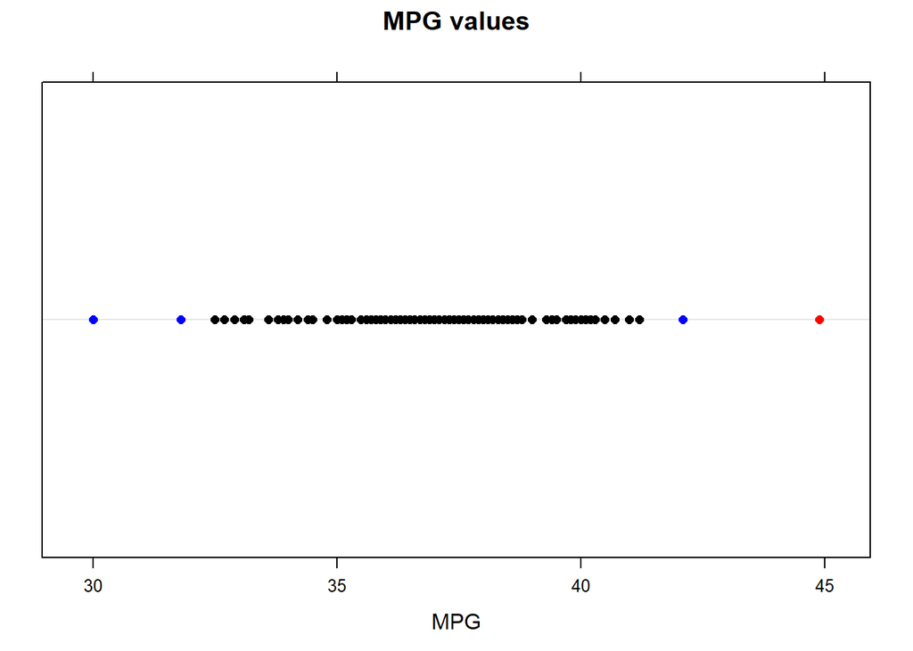

```r
mpgcolor = ifelse(abs(z)>3, "Red",
               ifelse(abs(z)>=2 & abs(z)<=3, "Blue",
                      "Black"))

library(lattice)
dotplot(mpg, col = mpgcolor, xlab = "MPG", main = "MPG values")
```

## Task 4

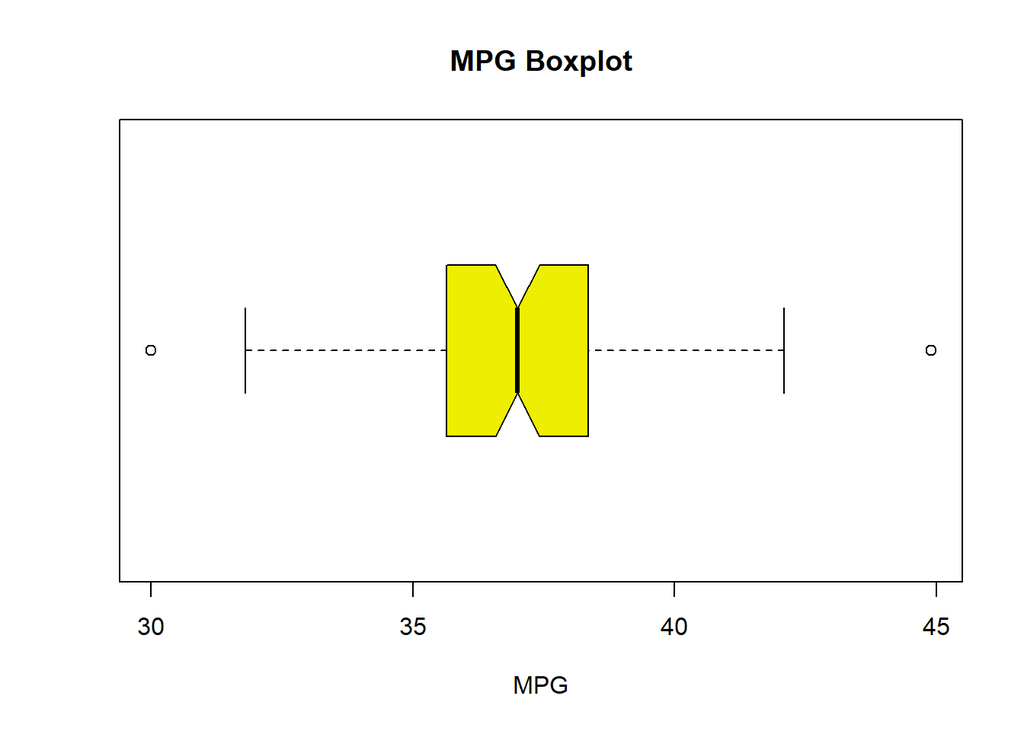

```r
boxplot(mpg, main = "MPG Boxplot", col = "yellow2", xlab = "MPG", horizontal = TRUE, notch = TRUE)
```

### Chebyshev’s Theorem

Chebyshev’s themoem represented by
$$1 - \frac{1}{k^2}$$
predicts what percentage of our data will fall within k standard deviations of the mean. Below we use the theorem

Chebyshev’s predicted proportion of data within two standard deviations:

```r
k = 2
chebyshev = 1 - 1/(k^2)
chebyshev
```

```
## [1] 0.75
```

The exact proportion of data within standard deviations:

```r
extprop = length(mpg[abs(z) < 2]) / length(mpg)
extprop
```

```
## [1] 0.96
```

### Empirical Rule

The empirical rule states that in any normal distribution nearly all data will fit within three standard deviations of the mean. It states that approximately 95% of the data will fall within two standard deviations if it is a normal distribution.

```r
empirical = length(mpg[mean(mpg)-2*sd(mpg) < mpg & mpg < mean(mpg)+ 2*sd(mpg) ])/length(mpg)
empirical
```

```
## [1] 0.96
```

Based on the calculations above, the empirical rule is valid as 96% of the data falls within the two standard deviations the mean which is slightly greater than the predicted 95% the empirical rule defines. This means the data set follows a normal distribution which can be visualized by the boxplot in section 4 and the dot plot in section 3.